# Exercise: Two-way ANOVA in R

Author

Stephan Huber

Published

June 4, 2024

Abstract

This is an exercise where data management with the `dplyr` functions `pivot_longer`, `rename`, and `bind_rows` is practiced. Moreover, I exemplify how an ANOVA analysis can be executed with R. Doing so I refer to the content of Childs et al. (2021, Chapter 27). All data to this exercise can be found in Huber (2024).

# Read

Read Childs et al. (2021): [27.2 Competition between Calluna and Festuca](https://dzchilds.github.io/stats-for-bio/two-way-anova-in-r.html).

Our goal is to learn how to work with two-way ANOVA models in R, using an example from a plant competition experiment. The work flow is very similar to one-way ANOVA in R. We’ll start with the problem and the data, and then work through model fitting, evaluating assumptions, significance testing, and finally, presenting the results.

# Set up the R session

Download and open the script that you find [here](https://raw.githubusercontent.com/hubchev/ewa/main/rmd_festuca/r_festuca.R). This script contains all the code that is shown below. The solutions to the exercises can be found [here](https://raw.githubusercontent.com/hubchev/ewa/main/rmd_festuca/r_festuca_solutions.R).

```r
rm(list = ls())

if (!require(pacman)) install.packages("pacman")
pacman::p_load(tidyverse, rstatix, ggpubr, agricolae)
```

# Create a data frame

Plants have an optimal soil pH for growth, and this varies between species. Consequently we would expect that if we grow two plants in competition with each other at different pH values the effect of competition might vary according to the soil pH. In a recent study the growth of the grass Festuca ovina (Sheep’s Fescue) in competition with the heather Calluna vulgaris (Ling) was investigated in soils with different pH. Calluna is well adapted to grow on very acidic soils such as on the Millstone grit and blanket bogs around Sheffield. Festuca grows on soils with a much wider range of pH. We might hypothesise that Calluna will be a better competitor of Festuca in very acid soils than in moderately acid soils. Here are the data: The column (Weight) contains the Festuca dry weights, (pH) contains the codes for the pH treatment (levels: pH3.5, pH5.5), the column (Calluna) contains the codes for the presence or absence of Calluna (levels: Present, Absent).

```r
data_present <- data.frame(
  Condition = rep(c("Calluna Present"), each = 5),
  `pH 3.5` = c(2.76, 2.39, 3.54, 3.71, 2.49),
  `pH 5.5` = c(3.21, 4.10, 3.04, 4.13, 5.21),
  check.names = FALSE
)
data_present
```

```
        Condition pH 3.5 pH 5.5
1 Calluna Present   2.76   3.21
2 Calluna Present   2.39   4.10
3 Calluna Present   3.54   3.04
4 Calluna Present   3.71   4.13
5 Calluna Present   2.49   5.21
```

```r
data_absent <- data.frame(
  Condition = rep(c("Calluna Absent"), each = 5),
  `pH 3.5` = c(4.10, 2.72, 2.28, 4.43, 3.31),
  `pH 5.5` = c(5.92, 7.31, 6.10, 5.25, 7.45),
  check.names = FALSE
)
data_absent
```

```
       Condition pH 3.5 pH 5.5
1 Calluna Absent   4.10   5.92
2 Calluna Absent   2.72   7.31
3 Calluna Absent   2.28   6.10
4 Calluna Absent   4.43   5.25
5 Calluna Absent   3.31   7.45
```

# Make the data “long”

Read the [R documentation](https://dplyr.tidyverse.org/reference/bind_rows.html) of the function `bind_rows` which is part of the `dplyr` package.

Combine the objects `data_present` and `data_absent`.

```
         Condition pH 3.5 pH 5.5
1  Calluna Present   2.76   3.21
2  Calluna Present   2.39   4.10
3  Calluna Present   3.54   3.04
4  Calluna Present   3.71   4.13
5  Calluna Present   2.49   5.21
6   Calluna Absent   4.10   5.92
7   Calluna Absent   2.72   7.31
8   Calluna Absent   2.28   6.10
9   Calluna Absent   4.43   5.25
10  Calluna Absent   3.31   7.45
```

Read Wickham & Grolemund (2023): [5.3 Lengthening data](https://r4ds.hadley.nz/data-tidy#sec-pivoting).

Rearrange the data so that they look like this:

```r
festuca
```

```
# A tibble: 20 × 3
   Calluna         pH     Weight
   <chr>           <chr>   <dbl>
 1 Calluna Present pH 3.5   2.76
 2 Calluna Present pH 5.5   3.21
 3 Calluna Present pH 3.5   2.39
 4 Calluna Present pH 5.5   4.1
 5 Calluna Present pH 3.5   3.54
 6 Calluna Present pH 5.5   3.04
 7 Calluna Present pH 3.5   3.71
 8 Calluna Present pH 5.5   4.13
 9 Calluna Present pH 3.5   2.49
10 Calluna Present pH 5.5   5.21
11 Calluna Absent  pH 3.5   4.1
12 Calluna Absent  pH 5.5   5.92
13 Calluna Absent  pH 3.5   2.72
14 Calluna Absent  pH 5.5   7.31
15 Calluna Absent  pH 3.5   2.28
16 Calluna Absent  pH 5.5   6.1
17 Calluna Absent  pH 3.5   4.43
18 Calluna Absent  pH 5.5   5.25
19 Calluna Absent  pH 3.5   3.31
20 Calluna Absent  pH 5.5   7.45
```

# Descriptive statistics

Calculate the following statistics and graphs:

```r
summary_stats
```

```
# A tibble: 4 × 4
  Calluna         pH      mean   var
  <chr>           <chr>  <dbl> <dbl>
1 Calluna Absent  pH 3.5  3.37 0.818
2 Calluna Absent  pH 5.5  6.41 0.893
3 Calluna Present pH 3.5  2.98 0.371
4 Calluna Present pH 5.5  3.94 0.754
```

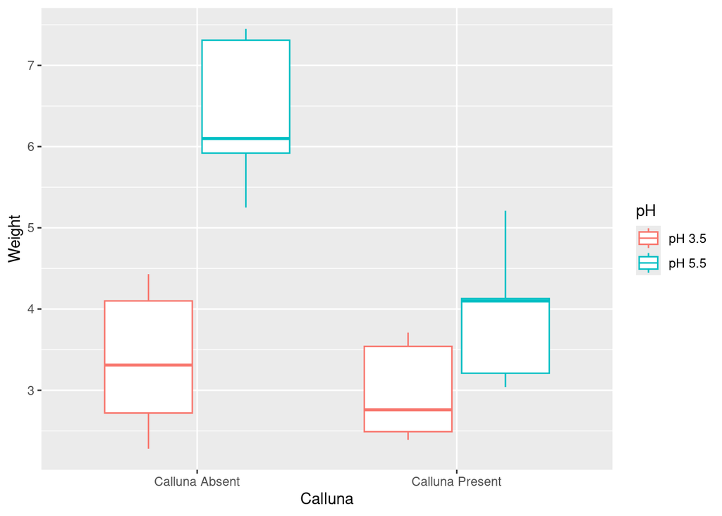

# ANOVA

Use this model to calculate the ANOVA: `Weight ~ pH + Calluna + pH:Calluna`

```
Analysis of Variance Table

Response: Weight
           Df  Sum Sq Mean Sq F value    Pr(>F)
pH          1 19.9800 19.9800 28.1792 7.065e-05 ***
Calluna     1 10.2102 10.2102 14.4001   0.00159 **
pH:Calluna  1  5.3976  5.3976  7.6126   0.01397 *
Residuals  16 11.3446  0.7090
---
Signif. codes:  0 '***' 0.001 '**' 0.01 '*' 0.05 '.' 0.1 ' ' 1
```

# Diagnostics

Read Childs et al. (2021): [27.5 Diagnostics](https://dzchilds.github.io/stats-for-bio/two-way-anova-in-r.html#diagnostics). Moreover, [this page](https://www.datanovia.com/en/lessons/anova-in-r/) is worth a look. You find some alternatives R functions that you may find helpful for ANOVA diagnostics.

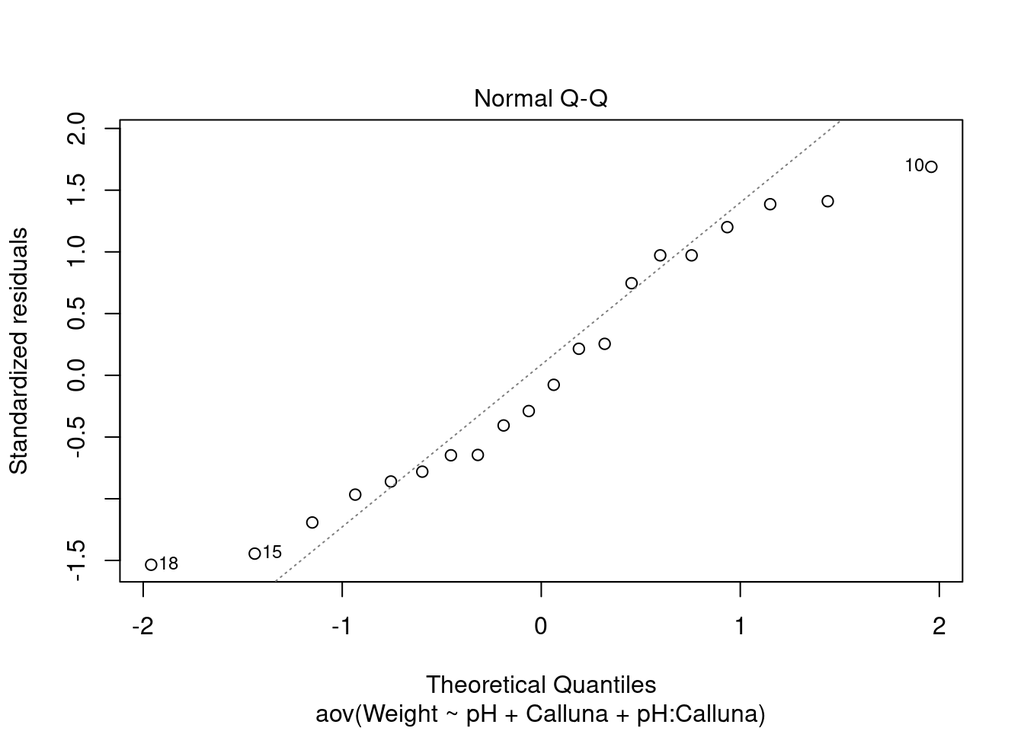

```r
plot(festuca_model, which = 2, add.smooth = FALSE)
```

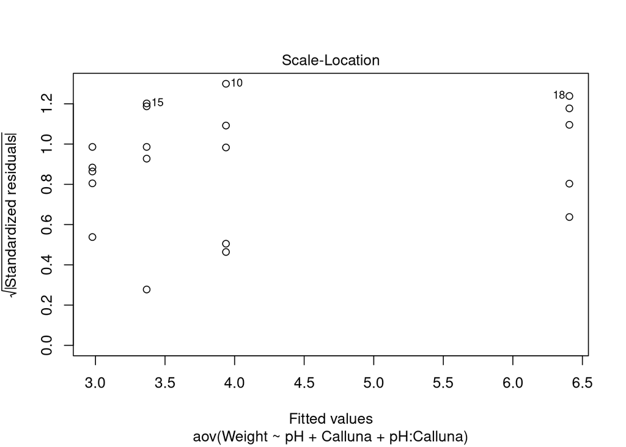

```r
plot(festuca_model, which = 3, add.smooth = FALSE)
```

# Interaction diagram

Can you use the function `interaction.plot` to create the following:

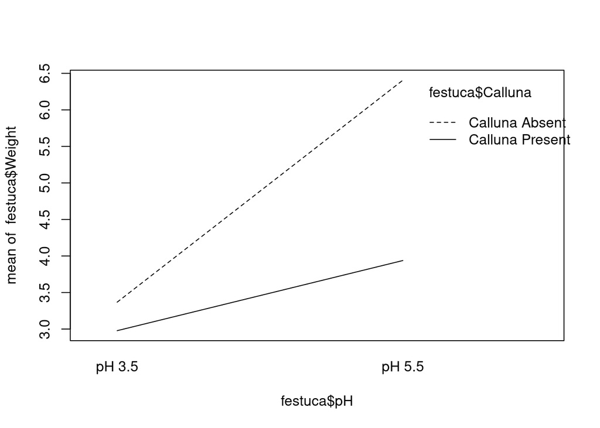

Here is a much nicer and more flexible approach to make interaction plots using `tidyverse` functions:

```r
# step 1. calculate means for each treatment combination
festuca_means <-
  festuca %>%
  group_by(Calluna, pH) %>% # <- remember to group by *both* factors
  summarise(Means = mean(Weight))
```

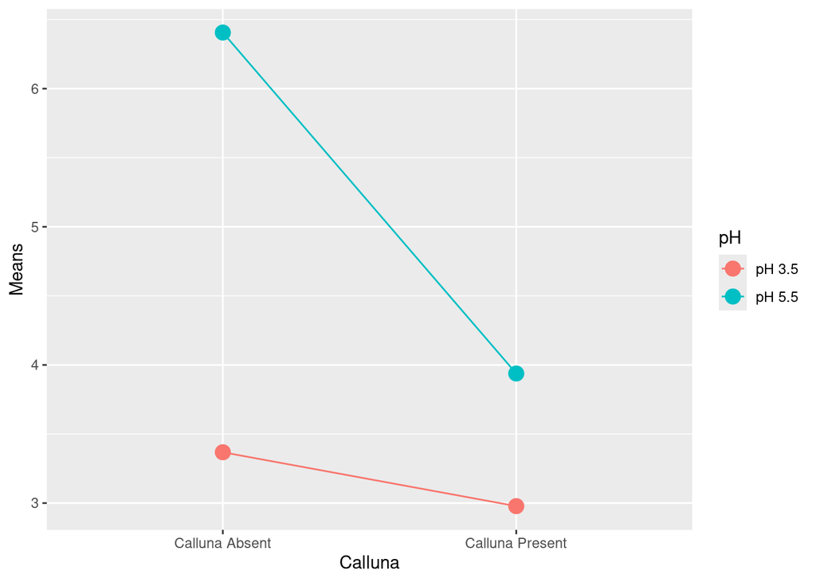

```r
# step 2. plot these as an interaction plot
ggplot(festuca_means,
       aes(x = Calluna, y = Means, colour = pH, group = pH)) +
  geom_point(size = 4) + geom_line()
```

Read Childs et al. (2021): [27.6.1](https://dzchilds.github.io/stats-for-bio/two-way-anova-in-r.html#understanding-the-model-graphically) and consider the following figure:

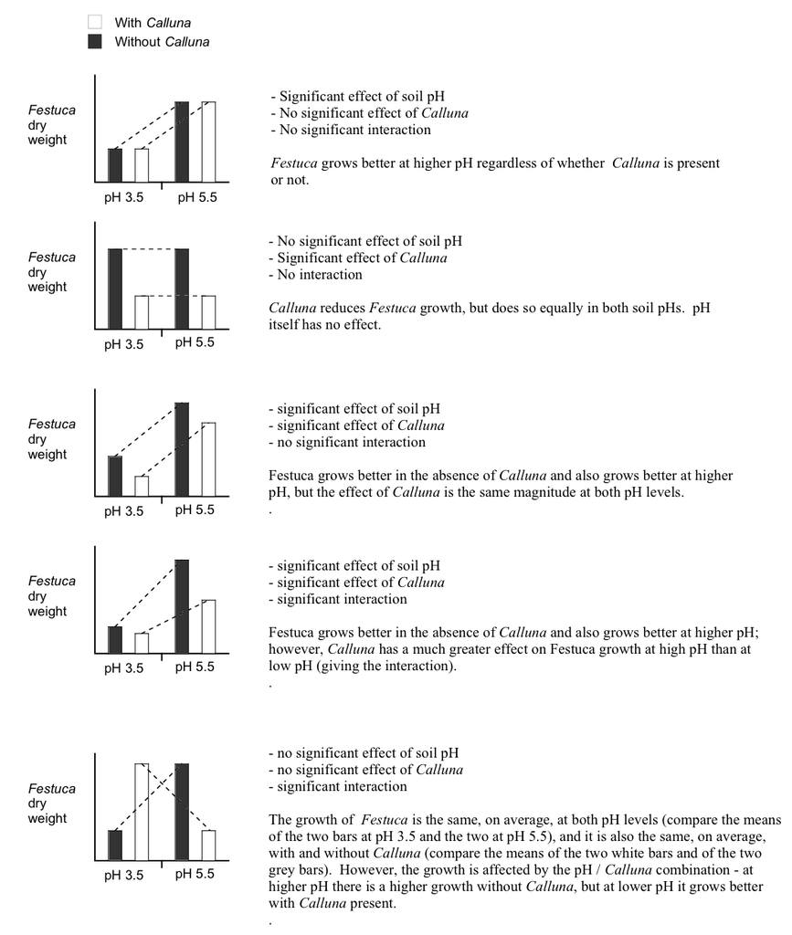

Understanding the model graphically

# Multiple comparison tests

```r
TukeyHSD(festuca_model, which = 'pH:Calluna')
```

```
  Tukey multiple comparisons of means
    95% family-wise confidence level

Fit: aov(formula = Weight ~ pH + Calluna + pH:Calluna, data = festuca)

$`pH:Calluna`
                                                diff        lwr        upr
pH 5.5:Calluna Absent-pH 3.5:Calluna Absent    3.038  1.5143518  4.5616482
pH 3.5:Calluna Present-pH 3.5:Calluna Absent  -0.390 -1.9136482  1.1336482
pH 5.5:Calluna Present-pH 3.5:Calluna Absent   0.570 -0.9536482  2.0936482
pH 3.5:Calluna Present-pH 5.5:Calluna Absent  -3.428 -4.9516482 -1.9043518
pH 5.5:Calluna Present-pH 5.5:Calluna Absent  -2.468 -3.9916482 -0.9443518
pH 5.5:Calluna Present-pH 3.5:Calluna Present  0.960 -0.5636482  2.4836482
                                                  p adj
pH 5.5:Calluna Absent-pH 3.5:Calluna Absent   0.0001731
pH 3.5:Calluna Present-pH 3.5:Calluna Absent  0.8826936
pH 5.5:Calluna Present-pH 3.5:Calluna Absent  0.7117913
pH 3.5:Calluna Present-pH 5.5:Calluna Absent  0.0000443
pH 5.5:Calluna Present-pH 5.5:Calluna Absent  0.0014155
pH 5.5:Calluna Present-pH 3.5:Calluna Present 0.3079685
```

[output not shown]

```
Study: festuca_model ~ c("pH", "Calluna")

HSD Test for Weight

Mean Square Error:  0.709035

pH:Calluna,  means

                       Weight       std r        se  Min  Max  Q25  Q50  Q75
pH 3.5:Calluna Absent   3.368 0.9042511 5 0.3765727 2.28 4.43 2.72 3.31 4.10
pH 3.5:Calluna Present  2.978 0.6089089 5 0.3765727 2.39 3.71 2.49 2.76 3.54
pH 5.5:Calluna Absent   6.406 0.9451614 5 0.3765727 5.25 7.45 5.92 6.10 7.31
pH 5.5:Calluna Present  3.938 0.8685448 5 0.3765727 3.04 5.21 3.21 4.10 4.13

Alpha: 0.05 ; DF Error: 16
Critical Value of Studentized Range: 4.046093

Minimun Significant Difference: 1.523648

Treatments with the same letter are not significantly different.

                       Weight groups
pH 5.5:Calluna Absent   6.406      a
pH 5.5:Calluna Present  3.938      b
pH 3.5:Calluna Absent   3.368      b
pH 3.5:Calluna Present  2.978      b
```

# Drawing conclusions and presenting results

Here are some code examples how the shown graphs above could be made much nicer.

```r
# step 1. calculate means for each treatment combination
festuca_stats <-
  festuca %>%
  group_by(Calluna, pH) %>% # <- remember to group by the two factors
  summarise(Means = mean(Weight), SEs = sd(Weight)/sqrt(n()))
```

```r
# step 1. calculate means for each treatment combination
festuca_stats <-
  festuca %>%
  group_by(Calluna, pH) %>% # <- remember to group by the two factors
  summarise(Means = mean(Weight), SEs = sd(Weight)/sqrt(n()))
```

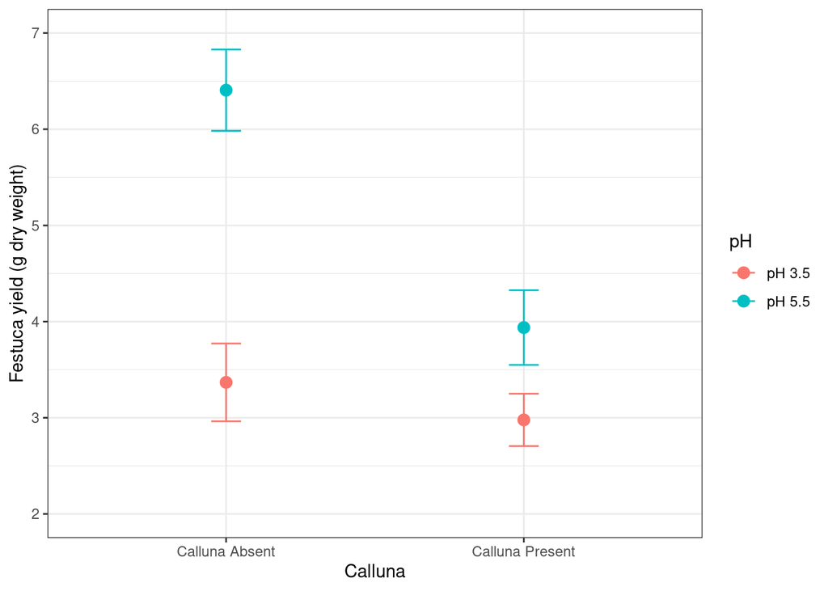

```r
# step 2. plot these as an interaction plot
ggplot(festuca_stats,
       aes(x = Calluna, y = Means, colour = pH,
           ymin = Means - SEs, ymax = Means + SEs)) +
  # this adds the mean
  geom_point(size = 3) +
  # this adds the error bars
  geom_errorbar(width = 0.1) +
  # controlling the appearance
  scale_y_continuous(limits = c(2, 7)) +
  xlab("Calluna") + ylab("Festuca yield (g dry weight)") +
  # use a more professional theme
  theme_bw()
```

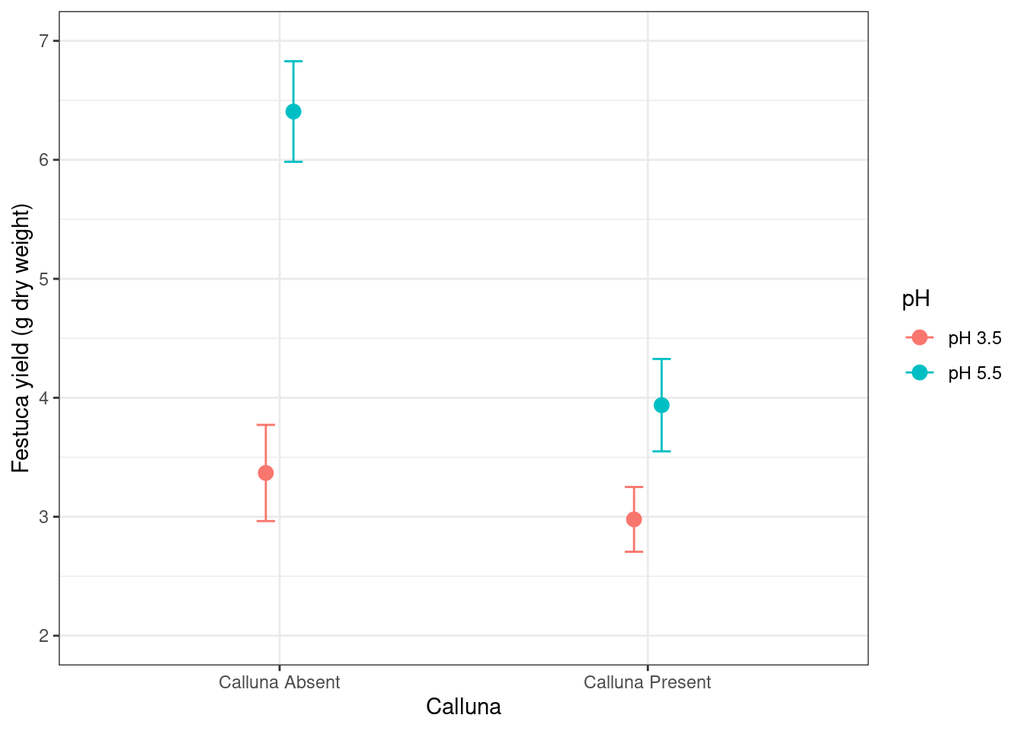

```r
# define a position adjustment
pos <- position_dodge(0.15)
# make the plot
ggplot(festuca_stats,
       aes(x = Calluna, y = Means, colour = pH,
           ymin = Means - SEs, ymax = Means + SEs)) +
  # this adds the mean (shift positions with 'position =')
  geom_point(size = 3, position = pos) +
  # this adds the error bars (shift positions with 'position =')
  geom_errorbar(width = 0.1, position = pos) +
  # controlling the appearance
  scale_y_continuous(limits = c(2, 7)) +
  xlab("Calluna") + ylab("Festuca yield (g dry weight)") +
  # use a more professional theme
  theme_bw()
```

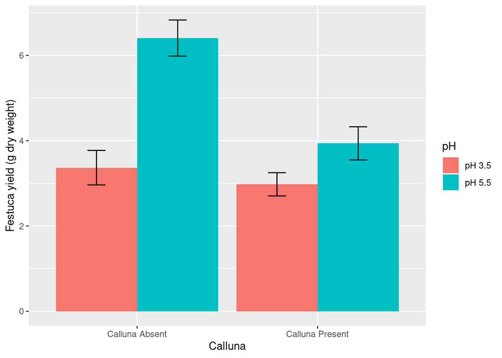

```r
ggplot(festuca_stats,
       aes(x = Calluna, y = Means, fill = pH,
           ymin = Means - SEs, ymax = Means + SEs)) +
  # this adds the mean
  geom_col(position = position_dodge()) +
  # this adds the error bars
  geom_errorbar(position = position_dodge(0.9), width=.2) +
  # controlling the appearance
  xlab("Calluna") + ylab("Festuca yield (g dry weight)")
```

## References

Childs, D. Z., Hindle, B. J., & Warren, P. H. (2021). *APS 240: Data analysis and statistics with r*. online. https://dzchilds.github.io/stats-for-bio

Huber, S. (2024). *Empirisch-wissenschaftlich arbeiten (ewa)*. GitHub repository. https://github.com/hubchev/ewa

Wickham, H., & Grolemund, G. (2023). *R for data science (2e)*. Accessed January 30, 2023. https://r4ds.hadley.nz/